# PPOL564 Project

12/2/2020

## Problem Statement

- What factors make it more or less likely for a restaurant
  - To be in the Michelin guide?
  - To get a Michelin star?

## Background

- Michelin
  - French tire manufacturer
  - Introduced the star rating system
    - One Star: high quality cooking, worth a stop
    - Two Stars: excellent cuisine, worth a detour
    - Three Stars: exceptional cuisine, worth a special journey
  - Only reviewed five cities in the U.S.
    - Washington, D.C.
    - Chicago
    - New York
    - San Francisco
    - Los Angeles

## Problem Statement

- Classification problem
  - Likelihood of being on the guide and get a star
- Predictors:
  - Yelp ratings and reviews
  - Cuisine of the restaurant
- Predicted outcomes:
  - 1 (in the guide) or 0 (not in the guide)
  - 1 (receive a star) or 0 (not receive a star)

## Methods

- Web Scraping
  - Yelp: rating, cuisine, price, reviews
  - Wikipedia: list of Michelin starred restaurants
  - Michelin Guide website
- Google Plaves API
  - Rating, menu, reviews, popular times
- Data Wrangling

## Methods

- Data Visualization
  - Bar graph
  - Pie chart
  - Map
- Machine Learning
  - What factors predict whether or not a restaurant will receive a star?
  - Which factor matters the most?

## Web Scraping

```python
# Yelp DC restaurants url
DC_url = 'https://www.yelp.com/search?find_desc=Restaurants&find_loc=Washington%2C%20DC'
```

[figure not shown]

```python
for i in range(10, DC_page_no*10, 10):
    DC_urls.update([DC_url+'&start='+str(i)])
list(DC_urls)[3]
```

```
## 'https://www.yelp.com/search?find_desc=Restaurants&find_loc=Washington%2C%20DC&start=160'
```

## Web Scraping

```python
Yelp_scraper(url=DC_url)
```

```
##                   business_name  ...                                     price_category
## 0       Gangster Vegan Organics  ...               Salad, Vegan, Juice Bars & Smoothies
## 1                  1. il Canale  ...                                   $$Italian, Pizza
## 2              2. Gypsy Kitchen  ...                  Tapas/Small Plates, Mediterranean
## 3               3. Le Diplomate  ...          $$$Brasseries, French, Breakfast & Brunch
## 4                     4. Maydan  ...                               $$Moroccan, Lebanese
## 5   5. Mr Braxton Bar & Kitchen  ...                    $$American (New), Cocktail Bars
## 6                       6. Cane  ...                                        $$Caribbean
## 7           7. Old Ebbitt Grill  ...  $$Bars, American (Traditional), Breakfast & Br...
## 8                      8. Ambar  ...                                  $$Modern European
## 9                    9. The Pig  ...           $$Barbeque, American (New), Whiskey Bars
## 10                    10. Reren  ...                              $$Ramen, Asian Fusion
##
## [11 rows x 4 columns]
```

## Data Wrangling

```python
DC_YW = (pd.merge(left = DC_Yelp, right = DC_Wiki, how = "left",
                  left_on = "business_name", right_on="Name")
         .drop(list(DC_Wiki.columns)[:-1],axis=1)
         .rename(columns={"2020":"michelin_star"}))
```

[output not shown]

```python
DC_YW.query('michelin_star != 0')
```

```
##     business_name  rating  review_count  michelin_star
## 17         Maydan     4.5           826              1
## 175  Tail Up Goat     4.5           677              1
```

## Preliminary Results

[figure not shown]

## Preliminary Results

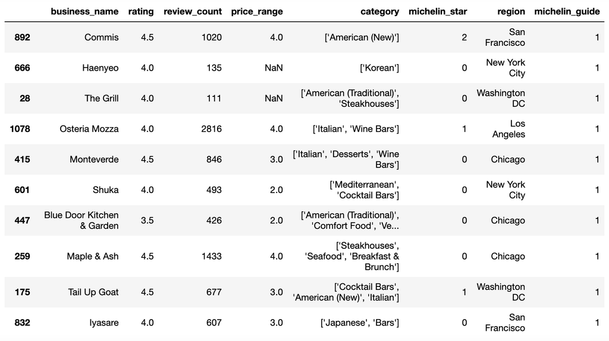

## Challenges

```python
len(dat.query('michelin_star != 0').index)
```

```
## 10
```

```python
len(dat.query('michelin_guide == 1').index)
```

```
## 127
```

```python
len(Michelin.index)
```

```
## 1429
```

## Challenges

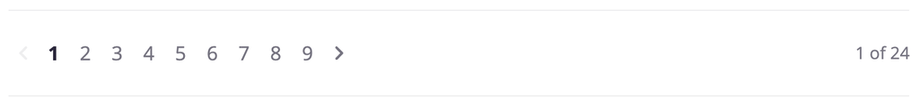

Yelp only shows 24 pages

[figure not shown]

Need to scrape multiple location points within a region

## Challenges

- Data is limited in scope
- Expand the set of predictors
  - Scrape Yelp reviews
  - Google Places API